# Reproducible Research: Peer Assessment 1

## Loading and preprocessing the data

1. Load the data (i.e. read.csv())
2. Process/transform the data (if necessary) into a format suitable for your analysis

```r
library(tidyverse)
activity<-read.csv(file = "activity.csv")
activity$date <- parse_date(activity$date)
sumna<-function(x){sum(is.na(x))}
apply(activity,2,sumna)
```

```
##    steps     date interval
##     2304        0        0
```

## What is mean total number of steps taken per day?

1. Calculate the total number of steps taken per day
2. If you do not understand the difference between a histogram and a barplot, research the difference between them. Make a histogram of the total number of steps taken each day
3. Calculate and report the mean and median of the total number of steps taken per day

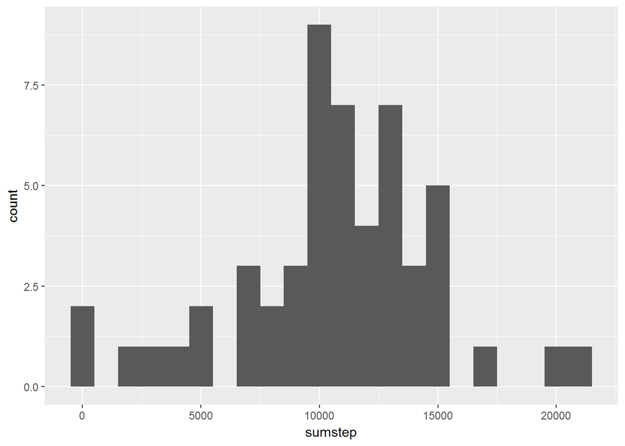

```r
activity1<-activity[!is.na(activity$steps),]
activity1 %>%
        group_by(date) %>%
        summarize(sumstep=sum(steps)) %>%
        ggplot(aes(sumstep))+
        geom_histogram(binwidth = 1000)
```

```r
activity1 %>%
        group_by(date) %>%
        summarize(sumstep=sum(steps)) %>%
        ungroup() %>%
        summarise(meanstep=mean(sumstep),
                  medianstep=median(sumstep))
```

```
## # A tibble: 1 × 2
##   meanstep medianstep
##      <dbl>      <int>
## 1 10766.19      10765
```

## What is the average daily activity pattern?

1. Make a time series plot (i.e. type = “l”) of the 5-minute interval (x-axis) and the average number of steps taken, averaged across all days (y-axis)
2. Which 5-minute interval, on average across all the days in the dataset, contains the maximum number of steps?

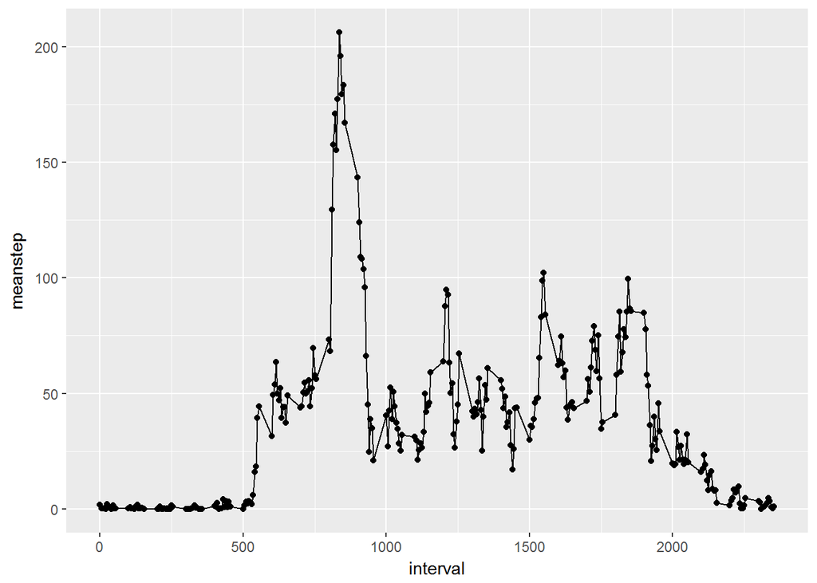

```r
activity1 %>%
        group_by(interval) %>%
        summarise(meanstep=mean(steps)) %>%
        ggplot(aes(x=interval,y=meanstep))+
        geom_point()+
        geom_line()
```

```r
stepsInterval <-activity1 %>%
        group_by(interval) %>%
        summarise(meanstep=mean(steps))
stepsInterval$interval[which.max(stepsInterval$meanstep)]
```

```
## [1] 835
```